# Prediction Assignment - Practical ML

Vibhuti Ravi

## Intro

A lot of data is constantly generated from fitness devices about personal movement and acticity. This data is used by people to track how much of a particular activity they have done most days. However, it is also important for these users to know how well they are performing the activity.

We will therefore be using this accelerometer data to predict how 6 participants carried out the exercise.

## Preprocessing the accelerometer data

```r
library(randomForest)
library(caret)
```

```r
library(rpart.plot)
library(corrplot)
library(rpart)
```

### Downloadind Data

```r
trainingu <- "https://d396qusza40orc.cloudfront.net/predmachlearn/pml-training.csv"
testingu <- "https://d396qusza40orc.cloudfront.net/predmachlearn/pml-testing.csv"
trainingcsv <- "./data1/pml-training.csv"
testingcsv  <- "./data1/pml-testing.csv"
if (!file.exists("./data1")) {
  dir.create("./data1")
}
if (!file.exists(trainingcsv)) {
  download.file(trainingu, destfile=trainingcsv)
}
if (!file.exists(testingcsv)) {
  download.file(testingu, destfile=testingcsv)
}
```

### Reading in the accelerometer Data

We will be using two dataframes for the two csv files

```r
trainingrawdata <- read.csv("./data1/pml-training.csv")
testingrawdata <- read.csv("./data1/pml-testing.csv")
dim(trainingrawdata)
```

```
## [1] 19622   160
```

```r
dim(testingrawdata)
```

```
## [1]  20 160
```

Training set : 19622 observations Testing data : 20 observations Both contain 160 variables. The outcome to be predicted is the “classe” variable.

### Cleaning

Removing missing and improper data

```r
sum(complete.cases(trainingrawdata))
```

```
## [1] 406
```

Removing NA values

```r
trainingrawdata <- trainingrawdata[, colSums(is.na(trainingrawdata)) == 0]
testingrawdata <- testingrawdata[, colSums(is.na(testingrawdata)) == 0]
```

Remove columns that do not make so much of a contribution

```r
classe <- trainingrawdata$classe
trainingRemove <- grepl("^X|timestamp|window", names(trainingrawdata))
trainingrawdata <- trainingrawdata[, !trainingRemove]
trainCleaned <- trainingrawdata[, sapply(trainingrawdata, is.numeric)]
trainCleaned$classe <- classe
testingRemove <- grepl("^X|timestamp|window", names(testingrawdata))
testingrawdata <- testingrawdata[, !testingRemove]
testCleaned <- testingrawdata[, sapply(testingrawdata, is.numeric)]
```

Training data: 19622 observations Testing data: 20 observations Both have 53 variables

### Slicing

We will be splitting the data into a validation set which will be 30% of the data and the rest 70% will be the training set. Crossing validation will be carried out later using the first set.

```r
set.seed(22519) # For reproducibile purpose
inTrain <- createDataPartition(trainCleaned$classe, p=0.70, list=F)
trainData <- trainCleaned[inTrain, ]
testData <- trainCleaned[-inTrain, ]
```

## Data Models

Here, it is essential that we use a model that is robust to outliers and automatically seletcs the more crucial variables. Therefore, the predictive model that will be used is the Random Forest algorithm and the 5 fold cross validation will be used.

```r
controlingRf <- trainControl(method="cv", 5)
modelingRf <- train(classe ~ ., data=trainData, method="rf", trControl=controlingRf, ntree=250)
modelingRf
```

```
## Random Forest
##
## 13737 samples
##    52 predictor
##     5 classes: 'A', 'B', 'C', 'D', 'E'
##
## No pre-processing
## Resampling: Cross-Validated (5 fold)
## Summary of sample sizes: 10988, 10989, 10989, 10991, 10991
## Resampling results across tuning parameters:
##
##   mtry  Accuracy   Kappa
##    2    0.9912654  0.9889499
##   27    0.9916291  0.9894104
##   52    0.9842766  0.9801110
##
## Accuracy was used to select the optimal model using the largest value.
## The final value used for the model was mtry = 27.
```

Estimating model,

```r
predictingRf <- predict(modelingRf, testData)
confusionMatrix(testData$classe, predictingRf)
```

```
## Confusion Matrix and Statistics
##
##           Reference
## Prediction    A    B    C    D    E
##          A 1669    2    3    0    0
##          B    5 1130    3    1    0
##          C    0    4 1019    3    0
##          D    0    0   10  954    0
##          E    0    0    4    2 1076
##
## Overall Statistics
##
##                Accuracy : 0.9937
##                  95% CI : (0.9913, 0.9956)
##     No Information Rate : 0.2845
##     P-Value [Acc > NIR] : < 2.2e-16
##
##                   Kappa : 0.992
##
##  Mcnemar's Test P-Value : NA
##
## Statistics by Class:
##
##                      Class: A Class: B Class: C Class: D Class: E
## Sensitivity            0.9970   0.9947   0.9808   0.9938   1.0000
## Specificity            0.9988   0.9981   0.9986   0.9980   0.9988
## Pos Pred Value         0.9970   0.9921   0.9932   0.9896   0.9945
## Neg Pred Value         0.9988   0.9987   0.9959   0.9988   1.0000
## Prevalence             0.2845   0.1930   0.1766   0.1631   0.1828
## Detection Rate         0.2836   0.1920   0.1732   0.1621   0.1828
## Detection Prevalence   0.2845   0.1935   0.1743   0.1638   0.1839
## Balanced Accuracy      0.9979   0.9964   0.9897   0.9959   0.9994
```

```r
accuracy <- postResample(predictingRf, testData$classe)
accuracy
```

```
##  Accuracy     Kappa
## 0.9937128 0.9920477
```

```r
oose <- 1 - as.numeric(confusionMatrix(testData$classe, predictingRf)$overall[1])
oose
```

```
## [1] 0.006287171
```

Therefore, the accuracy -> 99.37%. The out-of-sample error -> 0.63%.

## Prediction

Removing `problem_id` column,

```r
result <- predict(modelingRf, testCleaned[, -length(names(testCleaned))])
result
```

```
##  [1] B A B A A E D B A A B C B A E E A B B B
## Levels: A B C D E
```

## Figures

1. Correlation Matrix Visualization

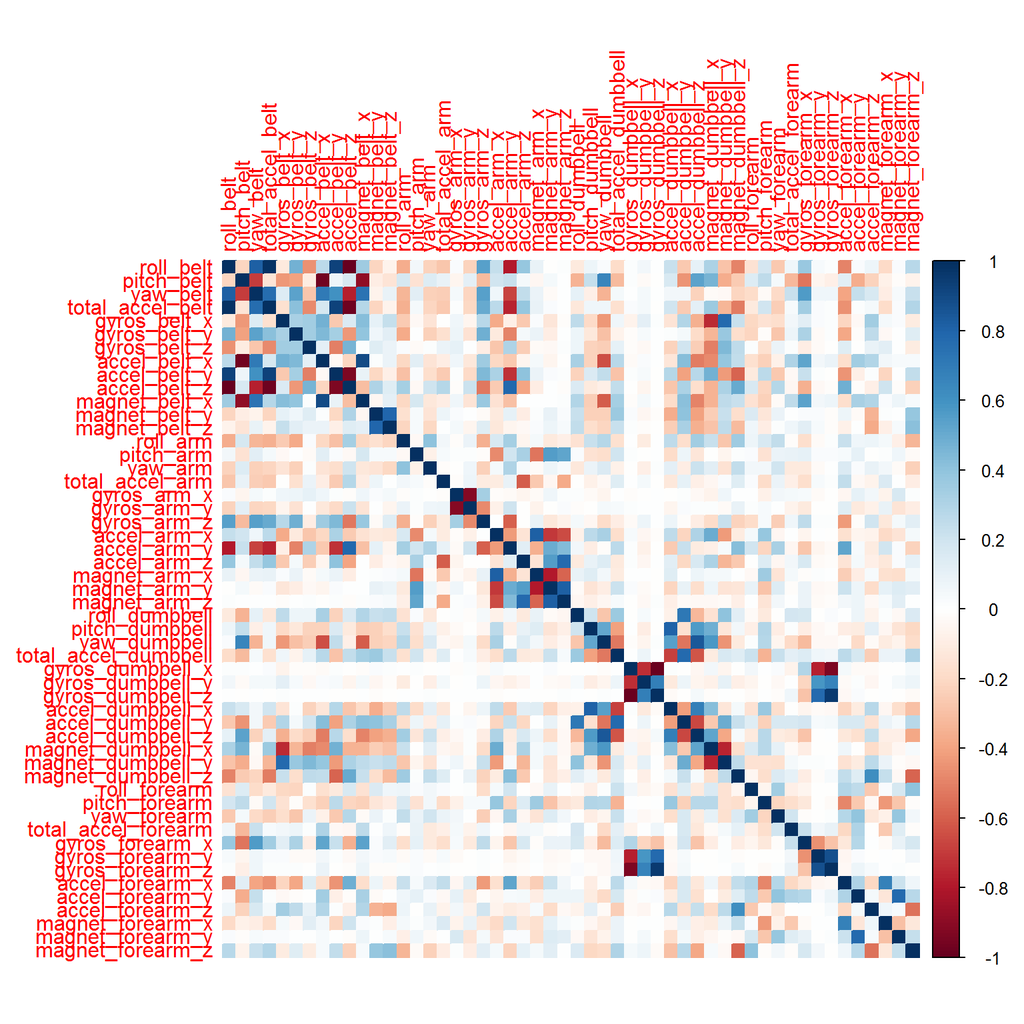

```r
corrPlot <- cor(trainData[, -length(names(trainData))])
corrplot(corrPlot, method="color")
```

2. Decision Tree Visualization

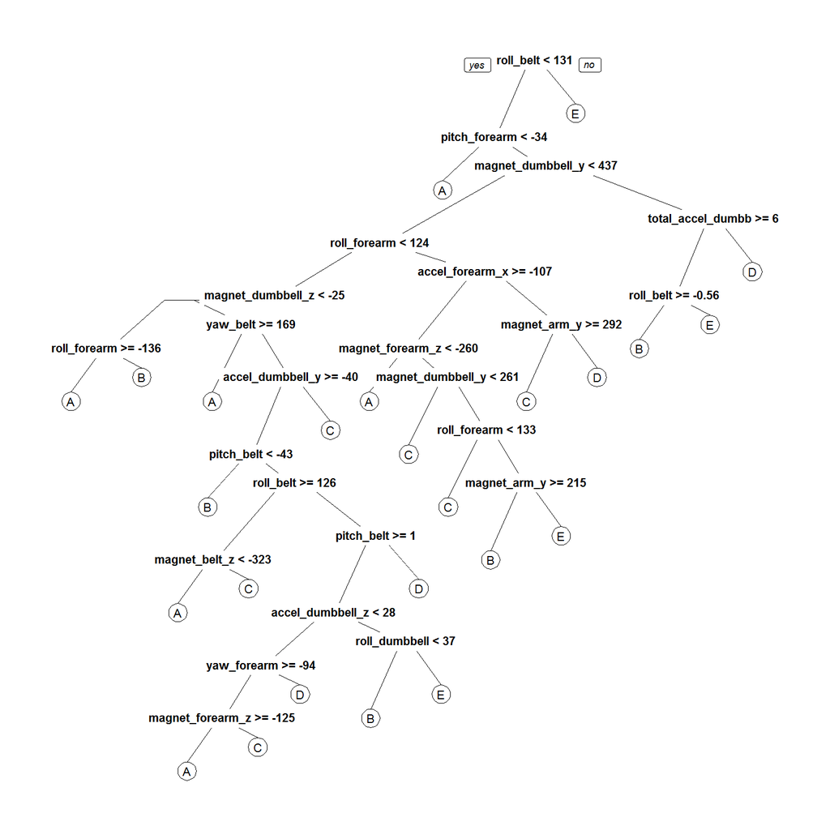

```r
treeModel <- rpart(classe ~ ., data=trainData, method="class")
prp(treeModel) # fast plot
```